# Introduction to Snakemake

# Introduction to Snakemake workflows

2024-10-15

Chloé QUIGNOT (BIOI2 @I2BC) - ORCID: 0000-0001-8504-232X

Source: adapted from FAIRbioinfo 2021 training material of the [IFB](https://moodle.france-bioinformatique.fr/course/view.php?id=5) and Snakemake introduction tutorial from [BIOI2](https://bioi2.i2bc.paris-saclay.fr/training/snakemake)

Material under [CC-BY-SA](https://creativecommons.org/licenses/by-sa/2.0/fr/deed.fr) licence

[figure not shown]

# The principle behind Snakemake

Snakemake = [Python](https://www.python.org/) (aka “snake”, a programming language) + [Make](https://www.gnu.org/software/make/manual/) (a rule-based automation tool)

## Workflows are like legos:

Workflows are **made up of blocks**, each block performs a specific (set of) instruction(s)

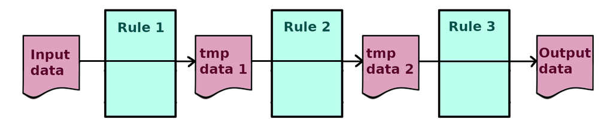

## 1 “block” = 1 rule:

|  | - **1 rule = 1 instruction** (ideally) - inputs and outputs are **one or multiple files** - at least 1 input and/or 1 output per rule |
| --- | --- |

# Linking data flows

## Rule order is not important…

execution order ≠ code order => Snakemake does a pick & mix of the rules it needs at execution

## …but matching file names is key!

Rules are linked together by Snakemake using matching filenames in their input and output directives.

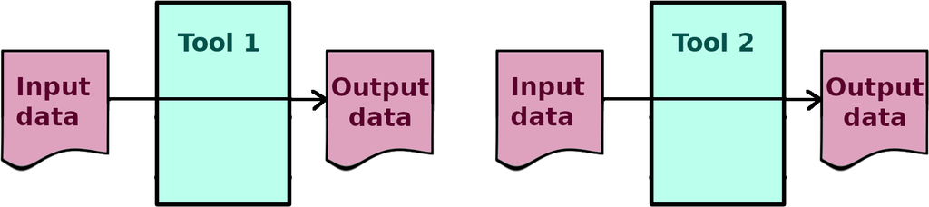

At execution, Snakemake creates a **DAG** (directed acyclic graph), that it will follow to generate the final output of your pipeline.

# A workflow example

Below is a workflow example using 2 tools sequentially to align 2 protein sequences:

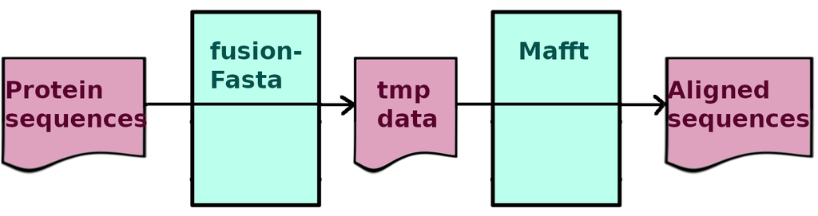

2-step example outline

In this example, we have:

- 2 linked rules: `fusionFasta` and `Mafft`
- input protein sequence files named `*.fasta`
- an intermediate file generated by fusionFasta named `*fused.fasta`
- the final output named `*aligned.fasta` generated by Mafft

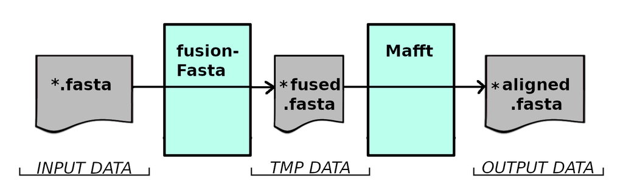

detailed illustration

# How Snakemake creates your workflow

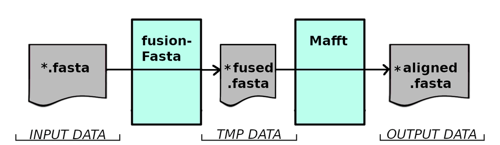

2-step example outline

# How Snakemake creates your workflow (summary)

| Snakemake (Smk) steps | running path |
| --- | --- |
| Smk creates the DAG from the snakefile |  |
| Smk sees that the final output `*aligned.fasta` doesn’t exist but knows it can create it with the `Mafft` rule |  |
| `Mafft` needs files matching `*fused.fasta` (don’t exist) but the `fusionFasta` rule can generate it |  |
| `fusionFasta` needs `.fasta` files |  |

# How Snakemake creates your workflow (summary)

| Snakemake steps | running path |
| --- | --- |
| `.fasta` files exist! Smk stops backtracking |  |
| Smk runs the `fusionFasta` rule |  |
| `P10415_P01308_fused.fasta` exists and feeds the `Mafft` rule |  |
| the final output (`P10415_P01308_aligned.fasta`) is generated, the workflow has finished |  |

# Rules are run when outputs are missing… but not only

Snakemake’s job is to **make sure** that everything is **up-to-date**, otherwise it (re-)runs the rules that need to be run…

Rules are run if:

- output doesn’t exist
- output exists but is older than the input
- changes detected in parameters, code or tool versions since last execution

# The Snakemake world

Many default files constitute the “Snakemake system” & there are standards on how to organise them.

They are not all necessary for a basic pipeline execution.

The most important is the `Snakefile`, that’s where all the code is saved.

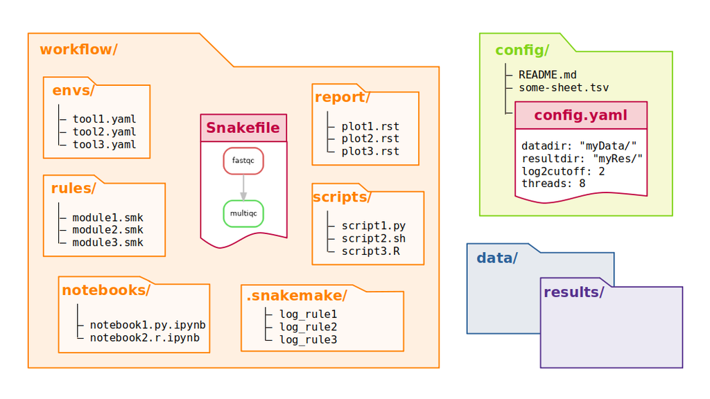

The Snakemake system

*For more information: https://github.com/snakemake-workflows/snakemake-workflow-template*

# Within the Snakefile…

- The Snakefile is where rules are defined
- The basic syntax of a rule is:

```
rule myRuleName:
    input: "myInputFile"
    output: "myOutputFile"
    shell: "echo {input} > {output}"
```

# Within the Snakefile…

- The Snakefile is where rules are defined
- The basic syntax of a rule is:

```
rule myRuleName:
    input: "myInputFile"
    output: "myOutputFile"
    shell: "echo {input} > {output}"
```

=> Rules usually have a **unique name** which defines them

# Within the Snakefile…

- The Snakefile is where rules are defined
- The basic syntax of a rule is:

```
rule myRuleName:
    input: "myInputFile"
    output: "myOutputFile"
    shell: "echo {input} > {output}"
```

=> Rules usually have a **unique name** which defines them  
=> `input`, `output`, `shell` etc. are called **directives**

# Within the Snakefile…

- The Snakefile is where rules are defined
- The basic syntax of a rule is:

```
rule myRuleName:
    input: "myInputFile"
    output: "myOutputFile"
    shell: "echo {input} > {output}"
```

=> Rules usually have a **unique name** which defines them  
=> `input`, `output`, `shell` etc. are called **directives**  
=> `"myInputFile"` & `"myOutputFile"` specify 1 or more input & output **files**

# Within the Snakefile…

- The Snakefile is where rules are defined
- The basic syntax of a rule is:

```
rule myRuleName:
    input: "myInputFile"
    output: "myOutputFile"
    shell: "echo {input} > {output}"
```

=> Rules usually have a **unique name** which defines them  
=> `input`, `output`, `shell` etc. are called **directives**  
=> `"myInputFile"` & `"myOutputFile"` specify 1 or more input & output **files**  
=> `shell` specifies **what to do** (shell commands in this case -> alternative directives exist)

# Within the Snakefile…

- The Snakefile is where rules are defined
- The basic syntax of a rule is:

```
rule myRuleName:
    input: "myInputFile"
    output: "myOutputFile"
    shell: "echo {input} > {output}"
```

=> Rules usually have a **unique name** which defines them  
=> `input`, `output`, `shell` etc. are called **directives**  
=> `"myInputFile"` & `"myOutputFile"` specify 1 or more input & output **files**  
=> `shell` specifies **what to do** (shell commands in this case -> alternative directives exist)  
=> `{input}` & `{output}` are **placeholders** & are replaced by input & output file names at execution

# Within the Snakefile…

- The Snakefile is where rules are defined
- The basic syntax of a rule is:

```
rule myRuleName:
____input: "myInputFile"
____output: "myOutputFile"
____shell: "echo {input} > {output}"
```

=> Rules usually have a **unique name** which defines them  
=> `input`, `output`, `shell` etc. are called **directives**  
=> `"myInputFile"` & `"myOutputFile"` specify 1 or more input & output **files**  
=> `shell` specifies **what to do** (shell commands in this case -> alternative directives exist)  
=> `{input}` & `{output}` are **placeholders** & are replaced by input & output file names at execution

=> code alignment (=indentations) is important  
=> files and `shell` directives should be given within quotes (`'`, `"` or `"""` for multi-line code)  
=> additional & optional directives exist, *e.g.*: `params:`, `resources:`, `log:`, etc. (we’ll see them later)

*For more information: https://snakemake.readthedocs.io/en/stable/snakefiles/rules.html*

# Snakefile of the previous example

```
rule fusionFasta:
    input:
        p1="P10415.fasta",
        p2="P01308.fasta",
    output:
        "P10415_P01308_fused.fasta",
    shell:
        """
        cat {input.p1} {input.p2} > {output}
        """

rule mafft:
    input:
        "P10415_P01308_fused.fasta",
    output:
        "P10415_P01308_aligned.fasta",
    shell:
        """
        mafft {input} > {output}
        """
```

- 2 rules: `fusionFasta` & `mafft`
- `fusionFasta`: 2 input (`p1` & `p2`) & 1 output file
- `mafft`: 1 input & 1 output file

NB: input & output files can be named  
e.g. `p1="P10415.fasta"`  
and explicitly accessed in `shell`  
e.g. `{input.p1}` or `{input[0]}`

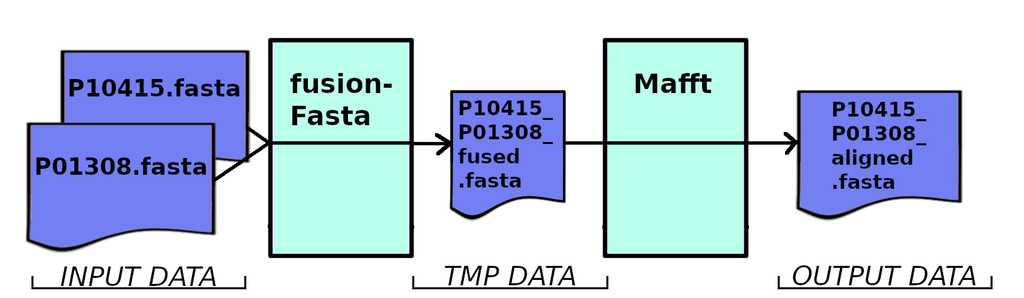

mafft alignment pipeline

# The concept of target rule

If you try running the previous example, it will only run `fusionFasta`, *why??!*

=> because in this case, `fusionFasta` is the **target rule**…

## What’s a target rule?

- it specifies the final result files that should be generated
- it’s the first (and “only”) rule executed by Snakemake
- if other rules are run, it’s only because they’re needed to create the files expected by the target rule

## How do you define a rule as target?

*Technically, any rule could be a target rule…*

- Default: first rule in the file (i.e. `fusionFasta`)
- Or: use `default_target: True` directive
- Or: specify the rule or its output in the command line at execution

*For more information: https://snakemake.readthedocs.io/en/stable/snakefiles/rules.html#target-rules/*

# Adding a target rule to the previous example

Here, we could make `mafft` the target rule. But it’s common practice to create a new dedicated rule, often called `target` or `all`. This rule will list all final output files of the pipeline.

[output not shown]

Here, we created a third rule called `all`.

It’s the target rule here because it’s the first rule in the Snakefile.

It lists all final output files of our pipeline.

# The power of wilcards

In Snakemake, rules can be **generalised** using *wildcards* to replace parts of file names:

- reduces hardcoding: more flexible input and output directives, and adaptable to new data without modification
- automatically resolved (ie. replaced by the regular expression: `".+"`)
- written between braces: `{}`
- *specific* per rule

A same file can be accessed using different patterns e.g. the file `101/file.A.txt` could be encoded:  
- `output : "{set}1/file.{grp}.txt"` in which case set=`10`, grp=`A`  
- `output : "{set}/file.A.{ext}"` in which case set=`101`, ext=`txt`  
- `output : "{filename}.txt"` in which case filename=`101/file.A`

The most important condition with wildcards: if they are used in both `input` and `output` directives, they should match (i.e. same number, same names). The names (or keywords) used are totally arbitrary.

*For more information on wildcards: https://snakemake.readthedocs.io/en/stable/snakefiles/rules.html#wildcards/*

# Adding wildcards to the previous example

Here, we generalised rules `fusionFasta` and `mafft` to any fasta input thanks to wildcards. In this case, the values of the given wildcards are deduced by Snakemake using the final output files defined in the `all` rule.

```
rule all:
    input: "P10415_P01308_aligned.fasta",

rule fusionFasta:
    input:
        p1="{upid1}.fasta",
        p2="{upid2}.fasta",
    output:
        "{upid1}_{upid2}.fasta",
    shell:
        """
        cat {input.p1} {input.p2} > {output}
        """

rule mafft:
    input:
        "{prefix}.fasta",
    output:
        "{prefix}_aligned.fasta",
    shell:
        """
        mafft {input} > {output}
        """
```

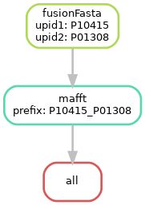

# A last word about wildcards

## adding constraints

You can change the default regex of given wildcards with the `wildcard_constraints:` directive

For example:

- regex: `wildcard_constraints: upid1="[A-Z0-9]+"`
- list of values: `wildcard_constraints: upid1="P10415|P01308"`

## accessing wildcards

- Within `input` & `output` directives: `{wildcard_name}`
- Within other directives **of the same rule**:
  - within `shell`: use the `wildcards` keyword, e.g. `shell: "echo {wildcards.upid1}"`
  - within other directives: use functions (will see this later)

# How to run a Snakemake pipeline?

When Snakemake is installed ([how to install](https://snakemake.readthedocs.io/en/stable/getting_started/installation.html)):

1. move into the directory containing the `Snakefile`
2. type `snakemake --cores 1` to run the pipeline (`--cores` specifies the number of cores to use)

# Snakemake’s monolog & it’s hidden treasure chest

When you run Snakemake, you’ll get a full report printed on the screen of its progress:

[output not shown]

When it’s finished, a `.snakemake` folder will appear in your working directory:

- it can be heavy (when using environments)
- it can contain a lot of files (unsuited for some file systems)
- it’s a hidden folder so `ls -a` to see it
- don’t forget to remove it *once you’re sure you’ve finished your analysis*

# Useful debugging options

## Visualise the Snakemake DAG

To visualise the complete workflow (`--dag`), rule dependencies (`--rulegraph`) or rule dependencies with their I/O files, in dot language. Uses the `dot` tool of the `graphviz` package to create a png, pdf or other format:

```
snakemake --dag | dot -Tpng > dag.png
snakemake --rulegraph | dot -Tpng > rule.png
snakemake --filegraph | dot -Tpng > file.png
```

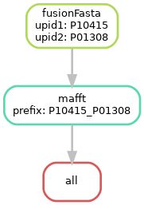

dag

[figure not shown]

file graph

## Use the `--dry-run` option

Using this option will perform a “dry-run” i.e. nothing will be executed but everything that would’ve been run is displayed on the screen

## Other useful options for debugging when running Snakemake

- print the shell command that is run: `-p --printshellcmds`
- print a summary and status of rule: `-D`, e.g.

| output_file | date | rule | log-file(s) | input-file(s) | shellcmd | status | plan |  |
| --- | --- | --- | --- | --- | --- | --- | --- | --- |
| `P10415.fasta` | 01/10/24 | loadData |  |  | `wget https://www.uniprot.org/uniprot/P10415.fasta` | ok | no update |  |

*All command line options: https://snakemake.readthedocs.io/en/stable/executing/cli.html#all-options*

# Conclusion

So far, we’ve seen:

- Snakemake workflow = set of rules
- Rules are written in Snakefiles
- Snakemake links rules together by matching up common input/output files
- Rules are defined by their name and contain directives (of which `input` and `output` to specify input & output files):

```
rule myRuleName
    input: "myInputFile"
    output: "myOutputFile"
    shell: "echo {input} > {output}"
```

- Snakemake only executes the target rule and only rules that will help in generating its files
- Rules can be generalised using `wildcards`
- A Snakefile is run with the `snakemake --cores 1` command (+ other options available)
- Debugging options: `--dag`, `--rulegraph`, `--filegraph` and `--dry-run`